# Modeling and Math

ECOTS R Workshop: May 21, 2014

## In Brief

The `mosaic` package provides facilities for putting model fitting into a “mathematical function” framework.

- Works with the workhorse `lm()` and `glm()`
- `mosaic::fitModel()` provides a named-parameter interface to fitting, both linear and nonlinear.
- Functions are easy and familiar to evaluate.
- `xyplot()` and `mosaic::plotFun()` allow students to display the model functions over the data.

### Use with lm( ), glm( )

#### Example:

Mortality at 20 years of follow-up for smokers and non-smokers.

```r
sample( Whickham, size=5 )
```

```
##      outcome smoker age orig.ids
## 665    Alive     No  22      665
## 781    Alive     No  32      781
## 1062    Dead     No  67     1062
## 956     Dead     No  72      956
## 200    Alive     No  51      200
```

```r
smod <- glm( outcome=='Alive' ~ age*smoker, family='binomial',
             data=Whickham)
f <- makeFun(smod) # EXTRACT THE FUNCTION
```

Evaluation … For a 60-year old …

```r
f( age=60, smoker=c('Yes'))
```

```
##      1
## 0.5129
```

### Plot data and the functional form

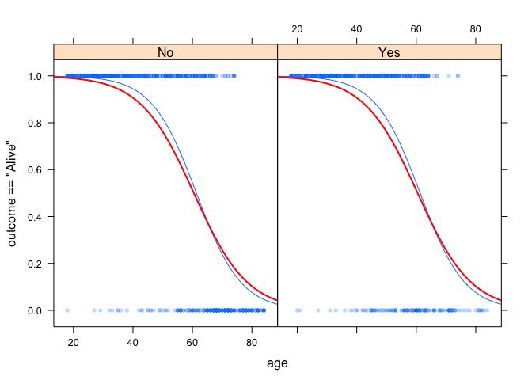

```r
xyplot( outcome=='Alive' ~ age | smoker, data=Whickham,
        pch=20, alpha=.2 )

plotFun( f(age=age, smoker="No") ~ age, add=TRUE)
plotFun( f(age=age, smoker="Yes") ~ age, add=TRUE,
         col='red', lwd=2)
```

### lm()

```r
hmod <- lm( height ~ father, data=subset(Galton,sex=="M"))
```

Extract the function … just like `resid( )` or `fitted( )`

```r
hfun <- makeFun(hmod)
```

Plot it … first data, then the function.

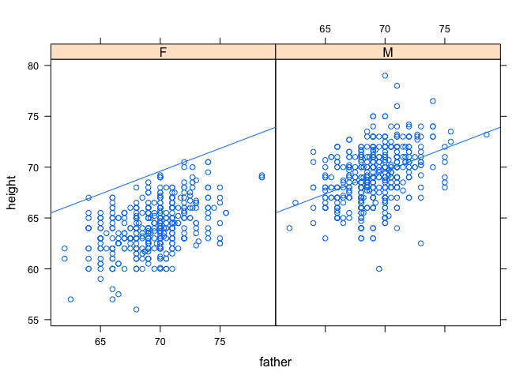

```r
xyplot(height ~ father | sex, data=Galton)
plotFun( hfun(x) ~ x, add=TRUE)
```

### Multiple variables:

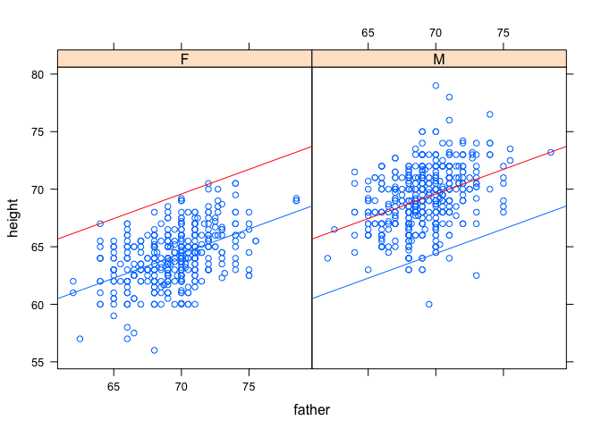

```r
mod2 <- lm( height ~ father + sex, data=Galton)
hfun2 <- makeFun(mod2)
xyplot(height ~ father | sex, data=Galton)
plotFun( hfun2(x, sex="F") ~ x, add=TRUE)
plotFun( hfun2(x, sex="M") ~ x, add=TRUE, col='red')
```

Or …

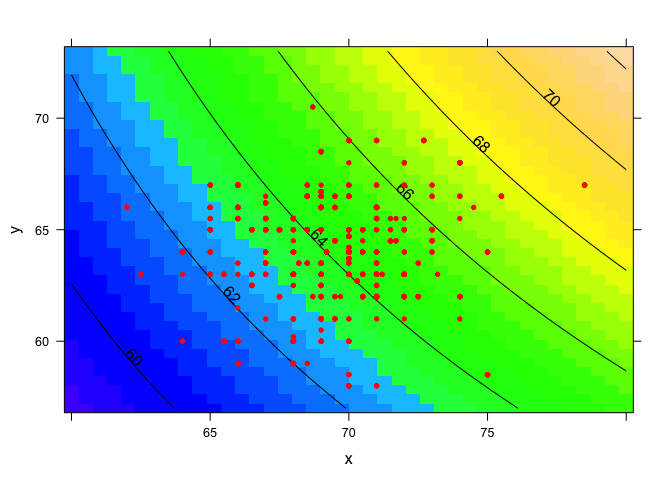

```r
mod3 <- lm( height ~ father*mother + sex, data=Galton)
hfun3 <- makeFun(mod3)
plotFun( hfun3(father=x, mother=y, sex="F") ~ x&y,
         x.lim=c(60,80),y.lim=c(57,73))
plotPoints( mother ~ father, data=Galton, add=TRUE,
            pch=20,col='red')
```

## Confidence Intervals

```r
hfun2( father=66, sex=c('M','F'), interval='confidence')
```

```
##     fit   lwr   upr
## 1 67.87 67.59 68.16
## 2 62.70 62.40 62.99
```

```r
hfun2( father=66, sex=c('M','F'), interval='prediction')
```

```
##     fit   lwr   upr
## 1 67.87 63.40 72.35
## 2 62.70 58.22 67.18
```

## NOTE: ggplot( ) does this well.

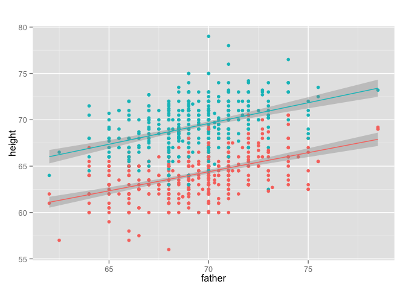

```r
ggplot(data=Galton, aes(x=father, y=height)) + geom_point()  +
  aes(colour=sex)  + stat_smooth(method=lm) +
  theme(legend.position="none") + labs(title="")
```

Convenient interface via `mosaic:mPlot()`.

[figure not shown]

## Not so brief introduction

One of the objectives of Project MOSAIC is to make connections between statistics and mathematics and computation. The `mosaic` package offers some features specifically oriented to doing math.

These are suggestions or demonstrations appropriate in teaching statistical modeling to students not afraid of math, e.g. engineers, statistics minors, …

```r
f <- makeFun( 3*x + 2 ~ x)
```

Read this as, “make a function `f` that takes $x$ as a input and produces $3x + 2$ as the output.

Evaluating the function is a matter of providing an input:

```r
f(4)
```

```
## [1] 14
```

It’s easy to plot functions:

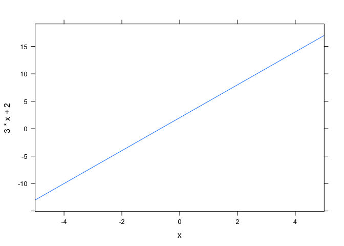

```r
plotFun( 3*x + 2 ~ x, x.lim=range(-5,5) )
```

Or, if we already have the function `f`, give $x$ as an input:

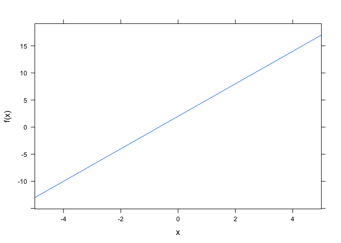

```r
plotFun( f(x) ~ x, x.lim=range(-5,5) )
```

Functions of multiple variables follow the same scheme:

```r
g <- makeFun( 3*x*y + 2*x -4*y +2 ~ x&y)
g(x=0,y=2)
```

```
## [1] -6
```

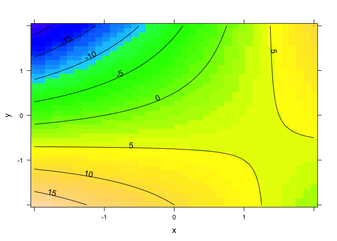

```r
plotFun( g(x=x,y=y)~x&y,
         x.lim=range(-2,2),y.lim=range(-2,2) )
```

Or even cross-sections or parametrically …

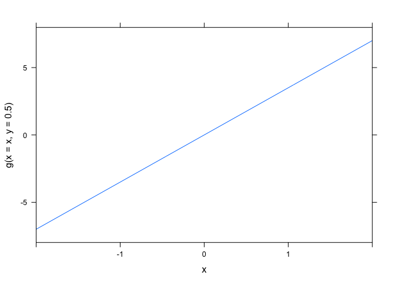

```r
plotFun( g(x=x, y=0.5) ~ x, x.lim=range(-2,2) )
```

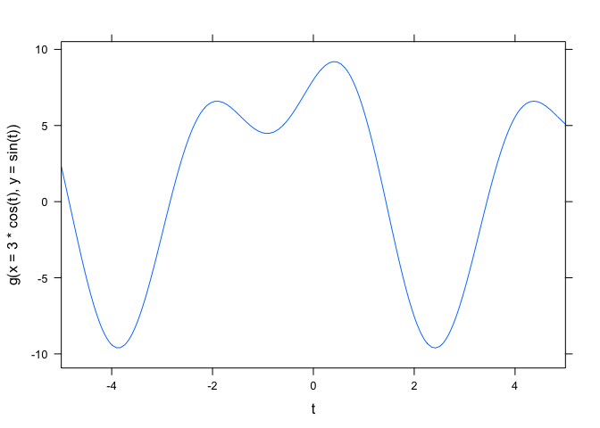

```r
plotFun( g(x=3*cos(t),y=sin(t))~ t, t.lim=range(-5,5))
```

Why is this relevant to statistical modeling?

## Statistical Conventions

The workhorses of model building in R are `lm()` and `glm()`. They are great, but unfortunately they return values that are not what students are used to.

In particular, students are used to lines expressed as $y = m x + b$, etc.

`lm()` gives back something different, e.g.

```r
lm( height ~ father, data=Galton )
```

```
## (Intercept)      father
##     39.1104      0.3994
```

How different this is from $mx+b$.

- Where’s the $+$?
- Where’s the $x$?
- Where’s the $y$?

And then, what happens when you plot a model …

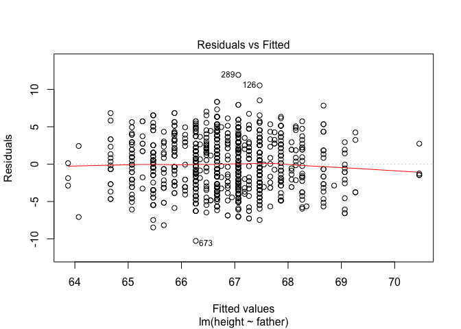

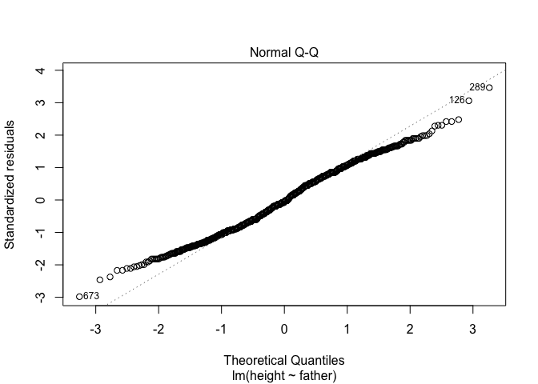

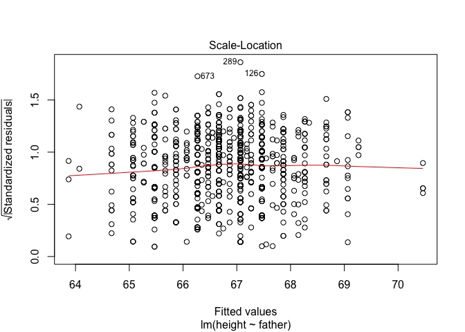

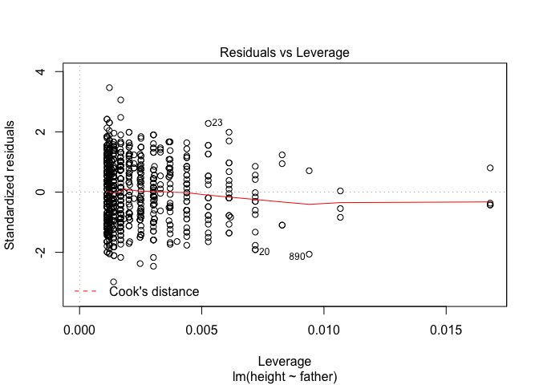

```r
m = lm( height ~ father, data=Galton )
plot(m)
```

## Where lm( ) shines

The `lm()` function was written by statisticians for statisticians. Confidence intervals and p-values are easy:

```r
coef(summary(m))
```

```
##             Estimate Std. Error t value  Pr(>|t|)
## (Intercept)  39.1104    3.22706  12.120 2.056e-31
## father        0.3994    0.04658   8.574 4.355e-17
```

`lm()` is particularly valuable when there are multiple explanatory variables.

```r
m2 <- lm( height ~ sex + father + mother, data=Galton)
coef(summary(m2))
```

```
##             Estimate Std. Error t value   Pr(>|t|)
## (Intercept)  15.3448    2.74696   5.586  3.082e-08
## sexM          5.2260    0.14401  36.289 5.787e-178
## father        0.4060    0.02921  13.900  6.526e-40
## mother        0.3215    0.03128  10.277  1.702e-23
```

## Overcoming the Differences

One strategy is to start with what students already know, and build on that.

1. Remind students that it’s really $y(x) = mx + b$: $y$ is a function of $x$. There are two variables involved.
2. Point out that $x$ and $y$ are simply names for variables.
   - We could write, e.g. $z(t) = mt + b$.
   - One more step takes us to mnemonic variable names, the height of a child taken as a function of the father’s height (as Galton put it). `height(father) = m * father + b`
3. Then introduce function fitting in the context of the function `height(father)`:
   - There’s some data: `Galton` in this case.
   - Variable names are set by the data:

     ```r
     names(Galton)
     ```

     ```
     ## [1] "family" "father" "mother" "sex"    "height" "nkids"
     ```

   - We don’t expect the child’s height to be exactly $=$, only approximately. So `height(father) ~ m * father + b`
4. And do the fitting:

   ```r
   f <- fitModel( height ~ m*father + b, data=Galton)
   ```

You plot this the same way as “mathematical” functions:

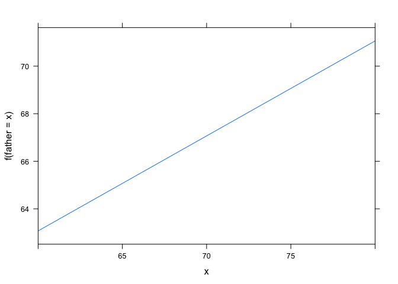

```r
plotFun( f(father=x)~x, x.lim=range(60,80) )
```

If you want to talk about residuals, least squares, etc, you can do so. For instance, have students guess the function before fitting it …

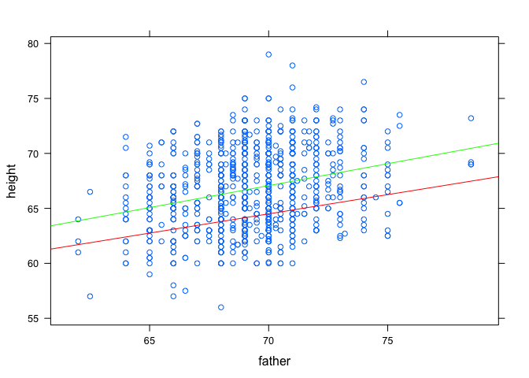

```r
xyplot( height ~ father, data=Galton)
myGuess <- makeFun(40 + .35*x ~ x )
plotFun( myGuess(x) ~ x, add=TRUE, col='red')
plotFun( f(father=x) ~ x, add=TRUE, col='green')
```

Which is better?

```r
mean( (myGuess(father)-height)^2, data=Galton )
```

```
## [1] 18.26
```

```r
mean( (f(father) - height)^2, data=Galton)
```

```
## [1] 11.85
```

Students can explore these questions:

- Why take the square?
- Oh … why couldn’t you take the absolute value?
  - Ans: You could.

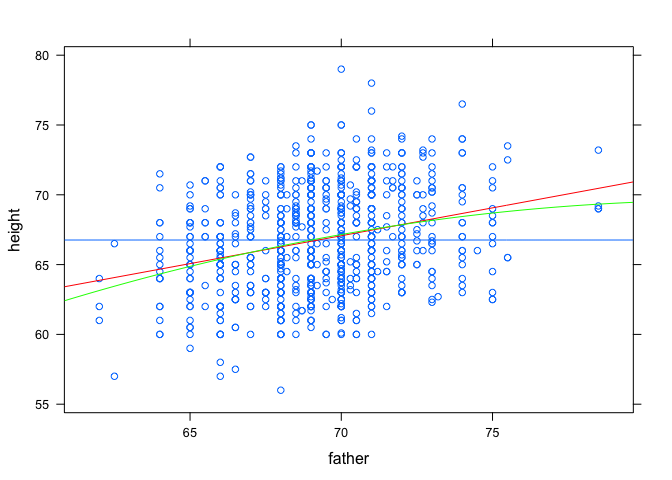

```r
f0 <- fitModel(height ~ a, data=Galton)
f1 <- fitModel(height ~ a + b*father, data=Galton)
f2 <- fitModel(height ~ a + b*father + c*father^2, data=Galton)

xyplot( height ~ father, data=Galton)
plotFun( f0(father=x)~x, add=TRUE)
plotFun( f1(father=x)~x, add=TRUE, col='red')
plotFun( f2(father=x)~x, add=TRUE, col='green')
```

```r
mean( (f0(father)-height)^2, data=Galton )
```

```
## [1] 12.82
```

```r
mean( (f1(father)-height)^2, data=Galton )
```

```
## [1] 11.85
```

```r
mean( (f2(father)-height)^2, data=Galton )
```

```
## [1] 11.83
```

### lm( ) makes a function.

It just isn’t packaged as such. We can do so with `mosaic::makeFun()`

```r
m1 <- lm( height ~ father, data=Galton)
g1 <- makeFun(m1)
g1( father=65 )
```

```
##     1
## 65.07
```

### Functions with more than 1 input

While we’re at it …

Let’s do what Galton never could: Include women!

And we can take a liberal view about how the child came to be: the father and the mother multiplying:

```r
mod <- lm( height ~ sex + father*mother, data=Galton )
f <- makeFun( mod )
f( sex='F', father=65, mother=65 )
```

```
##     1
## 62.59
```

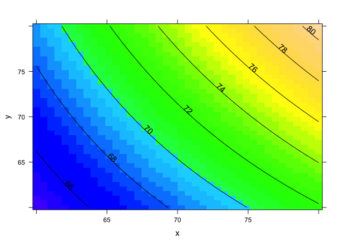

```r
plotFun( f(sex='M', father=x, mother=y) ~ x & y,
         x.lim=range(60,80), y.lim=range(60,80))
```

- What does the function look like without the interaction?
- What if you include the child’s sex as an interaction?

### Functions more generally

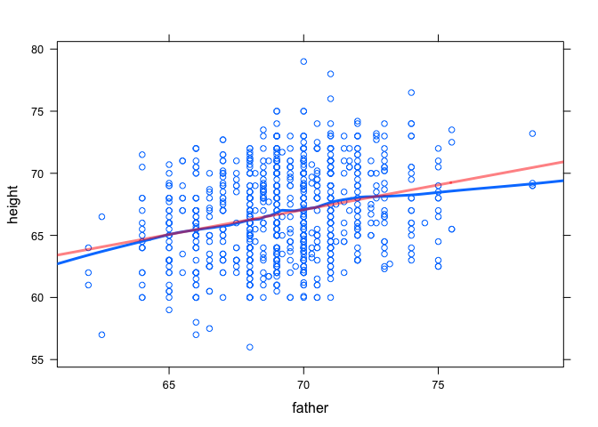

```r
g <- smoother( height ~ father, data=Galton, degree=1 )
xyplot(height ~ father, data=Galton)
plotFun( g(father=x)~x, add=TRUE, lwd=3 )
plotFun( f1(father=x)~x, add=TRUE, col='red',
         lwd=3, alpha=.5)
```

Where the data are, the two functions are basically the same.

## Modeling probabilities

Example: Mortality at 20 years of follow-up for smokers and non-smokers.

```r
sample( Whickham, size=5 )
```

```
##      outcome smoker age orig.ids
## 665    Alive     No  22      665
## 781    Alive     No  32      781
## 1062    Dead     No  67     1062
## 956     Dead     No  72      956
## 200    Alive     No  51      200
```

### A $\chi^2$-test? Really?

```r
counts <- tally( ~ outcome & smoker, data=Whickham )
chisq.test( counts )
```

```
##
##  Pearson's Chi-squared test with Yates' continuity correction
##
## data:  counts
## X-squared = 8.752, df = 1, p-value = 0.003093
```

And what’s the effect size? In what direction?

### Conditional Probabilities

```r
tally( outcome ~ smoker, data=Whickham )
```

```
##        smoker
## outcome     No    Yes
##   Alive 0.6858 0.7612
##   Dead  0.3142 0.2388
```

Really? Smokers had a larger chance of surviving?

### Models can include covariates

Just as there are smoothers, there are function types suited to Dead/Alive outcomes … e.g. logistic regression.

```r
smod <- glm( outcome=='Alive' ~ age*smoker, family='binomial',
             data=Whickham)
f <- makeFun(smod)
```

For a 60-year old …

```r
f( age=60, smoker=c('Yes','No'))
```

```
##      1      2
## 0.5129 0.5437
```

A function is a function, whatever the form!

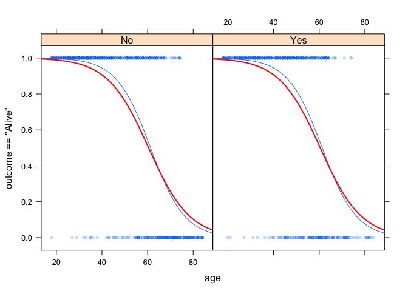

```r
xyplot( outcome=='Alive' ~ age | smoker, data=Whickham,
        pch=20, alpha=.2 )

plotFun( f(age=age, smoker="No") ~ age, add=TRUE)
plotFun( f(age=age, smoker="Yes") ~ age, add=TRUE,
         col='red', lwd=2)
```

### Inference

```r
actual <- lm(height ~ father+sex, data=Galton)
f <- makeFun( actual )
plotFun(f(x, sex='F')~x, x.lim=range(65,80))
# Confidence interval?
for (k in 1:50) {
  trial <- lm(height ~ father+sex, data=resample(Galton) )
  f <- makeFun( trial )
  print(plotFun(f(x, sex='F')~x, add=TRUE, col='blue', alpha=.5))
  1
  }
```

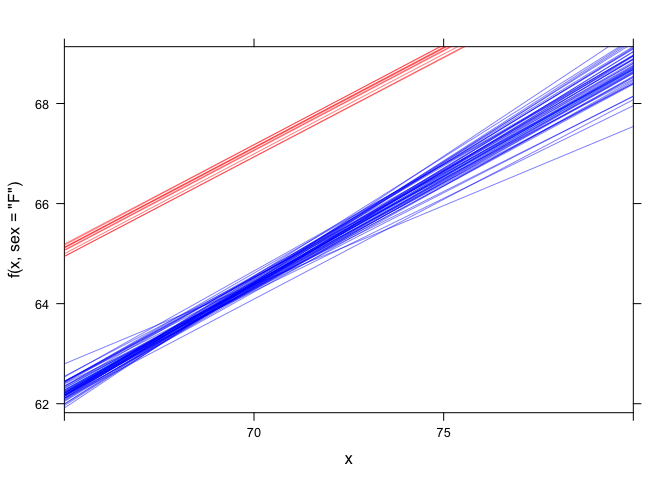

```r
# Null Hypothesis?
for (k in 1:10) {
  trial <- lm(height ~ father+shuffle(sex), data=Galton )
  f <- makeFun( trial )
  print(plotFun(f(x, sex='F')~x, add=TRUE, col='red', alpha=.5))
  1
  }
```